# General Mills Marketing Strategy of Cereal Products

Siqi Zhang

# Outline

- Introduction of Cereal Sales Analysis
  - Data Introduction
  - Current Cereal Sales Model
- Specific Marketing Strategy
  - Promotion only
  - Advertising only
  - Promotion and Advertising
- Conclusion and Recommendations
  - In store promotion and advertising volume have apparent affect on sales revenue.
  - Give appropriate promotion discount and apply wise advertising strategy based on different cereal flavors.

# Introduction of Cereal Sales Analysis

- Data Introduction
  - Sample of **21850** observations
  - Focus on
    - Producers: **General Mills, Kelloggs, Post**
    - **Sale Revenue**=(Price*Units)
    - **Flavor**
    - **In Store Promotion**
    - **Advertising Volume**
  - No bias [use the centrality of numeric data (**median**)]
- Current Cereal Sales Model

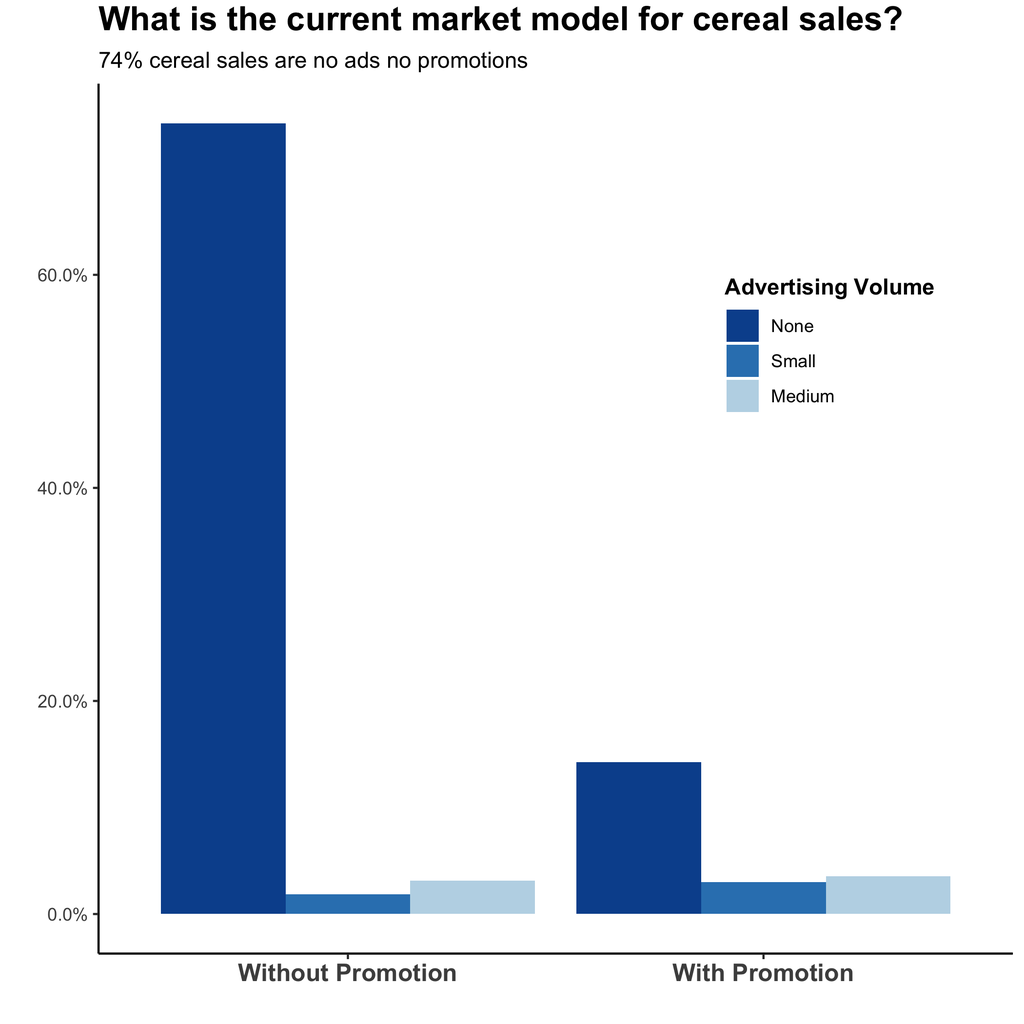

# Specific Marketing Strategy 1 – Promotion Only

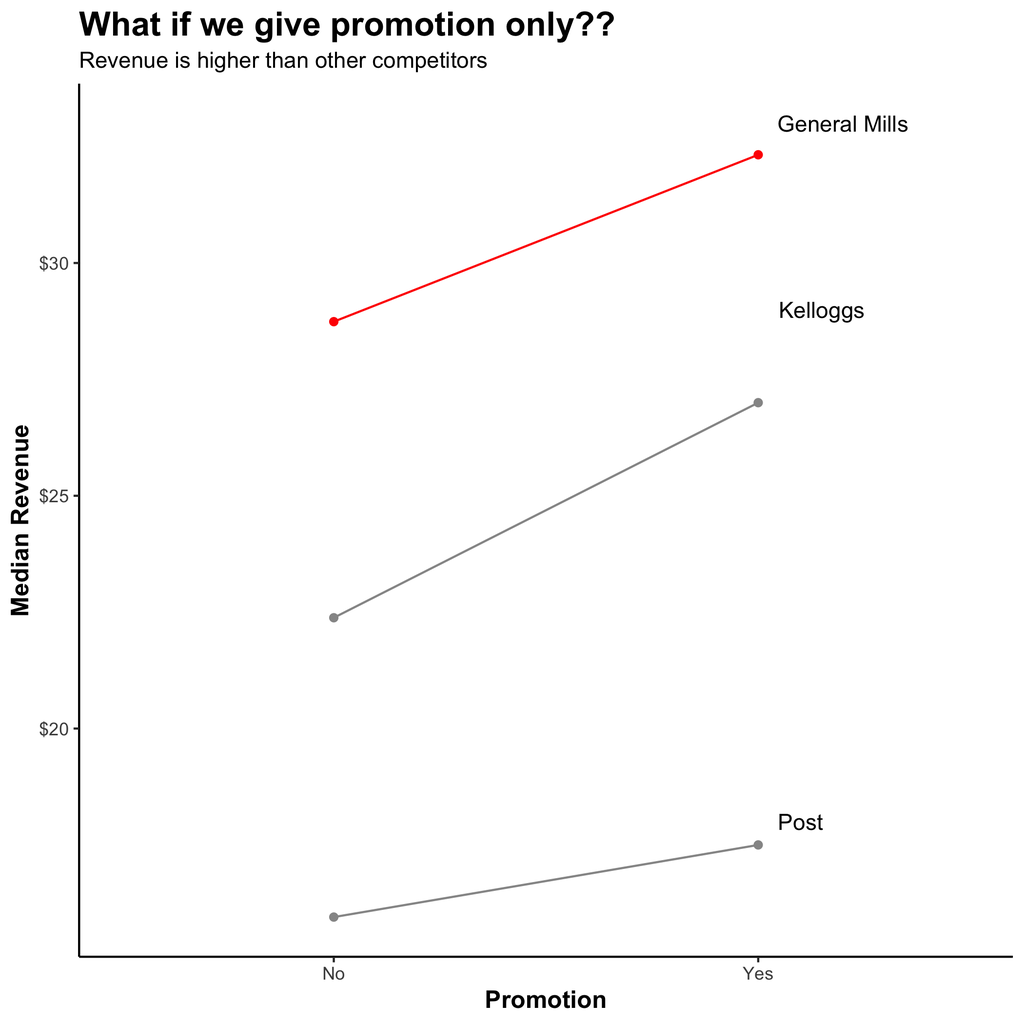

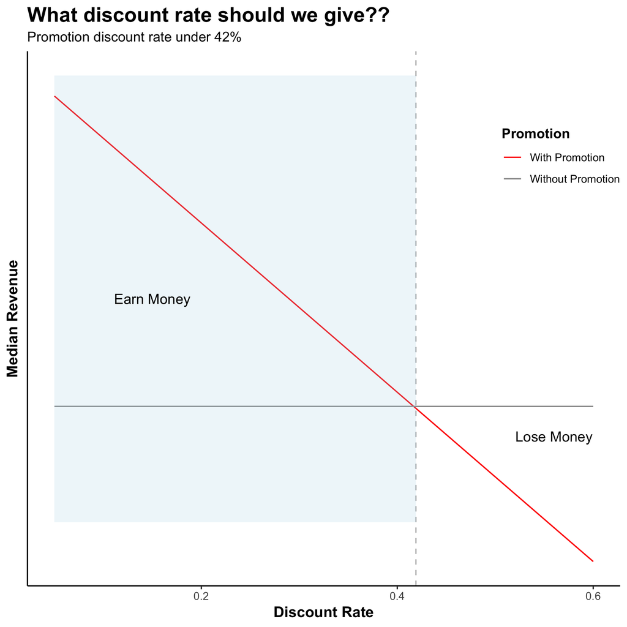

# Specific Marketing Strategy 2 – Advertising Only

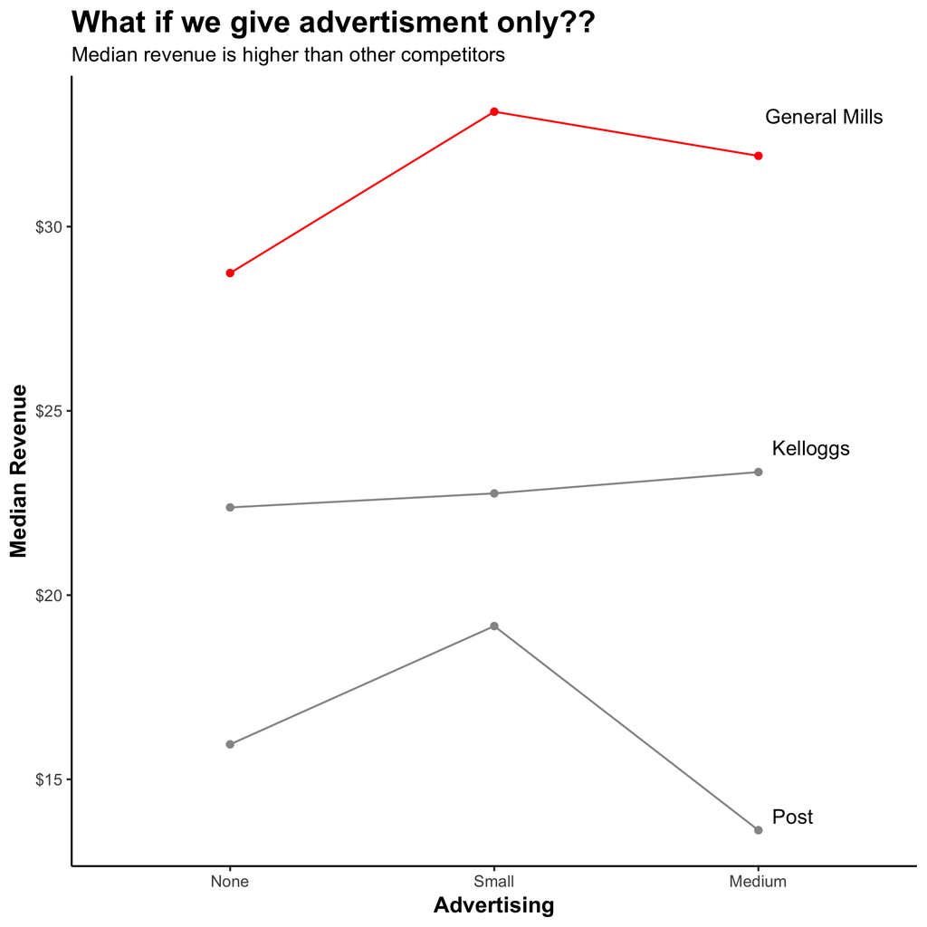

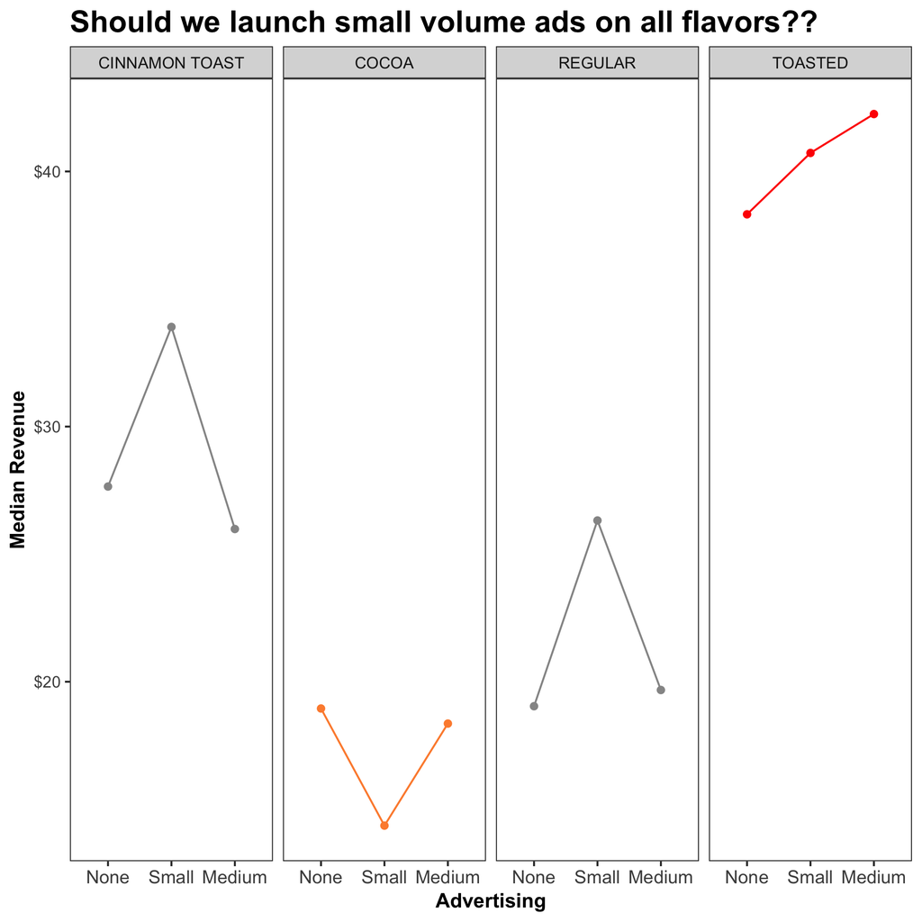

# Specific Marketing Strategy 3 – Promotion and Advertising

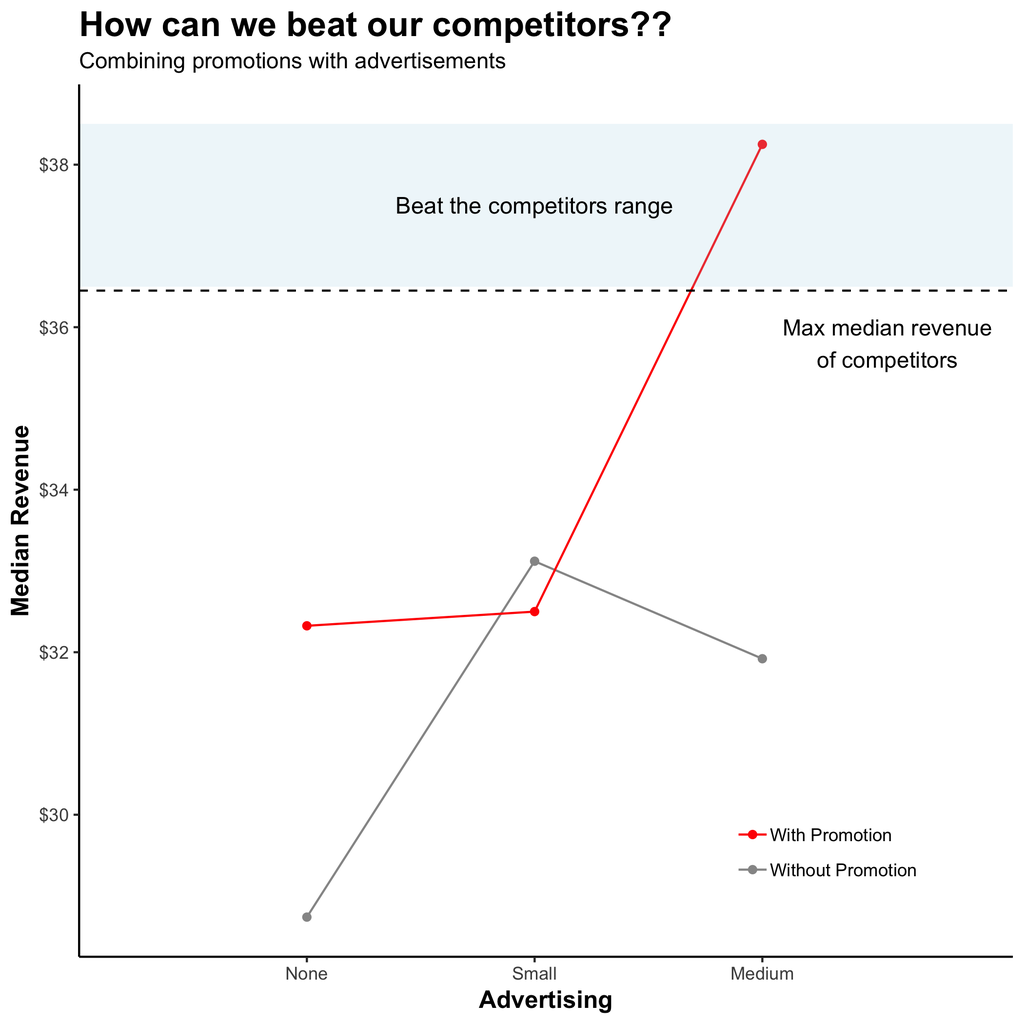

# Conclusion and Recommendations

- Conclusion
  - Promotion and Advertising can help increase our revenue
    - consistent with our statistical analysis
- Recommendations
  - If promotion only
    - giving promotion discount rate **under 42%**
  - If giving advertising only
    - giving **small volume advertising** overall, or
    - giving **no advertising on cocoa**, **small volume advertising** on **cinnamon toast** flavor and **regular** flavor, **medium advertising** on **toasted** flavor
  - We’d better **combining advertising and promotion together**

(Contact Info: zhangsiqi@seattleu.edu)